# 131_HW5

Exercise 6

```r
# fitting models to folded data
tune_en <- tune_grid(
  en_workflow,
  resamples = pokemon_folds,
  grid = en_grid)

save(tune_en, file="tune_en.rda")
```

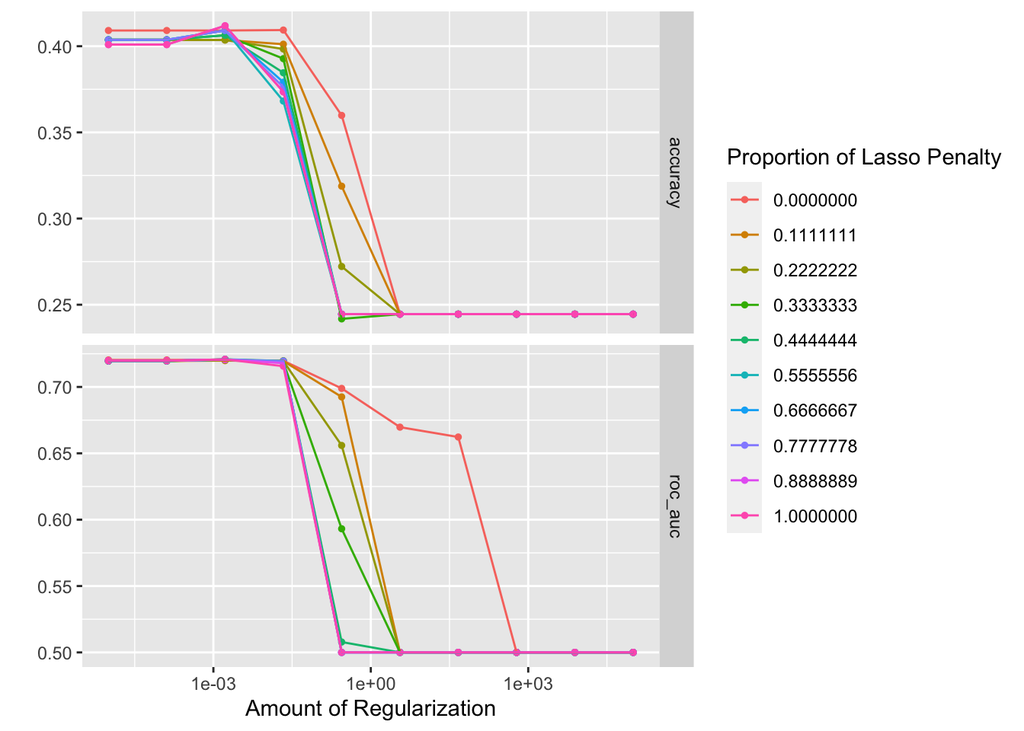

```r
load("tune_en.rda")

# use autoplot on results
autoplot(tune_en)
```

It appears that a lower penalty typically produces higher accuracy and ROC AUC. Smaller values of penalty and mixture should correspond to better accuracy and ROC AUC.

Exercise 7

```r
# selecting model with best roc auc
best_penalty <- select_best(tune_en, metric="roc_auc")

# finalizing workflow
en_final <- finalize_workflow(en_workflow, best_penalty)

# fitting best model on whole training set
en_final_fit <- fit(en_final, data = pokemon_train)

# applying final model on testing set
predicted_data <- augment(en_final_fit, new_data = pokemon_test) %>%
  select(type_1, starts_with(".pred"))
```

Exercise 8

```r
# calculate overall ROC AUC on testing set
predicted_data %>% roc_auc(type_1, .pred_Bug:.pred_Water)
```

```
## # A tibble: 1 × 3
##   .metric .estimator .estimate
##   <chr>   <chr>          <dbl>
## 1 roc_auc hand_till      0.677
```

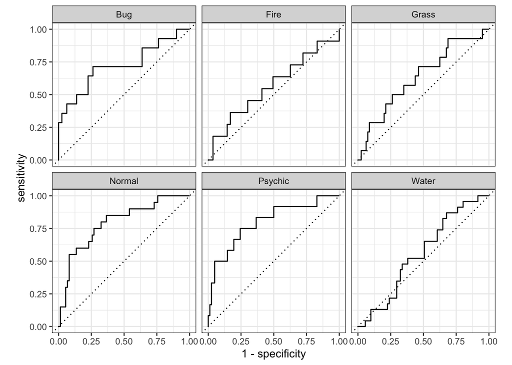

```r
# create plots of the different ROC curves
predicted_data %>% roc_curve(type_1, .pred_Bug:.pred_Water) %>% autoplot()
```

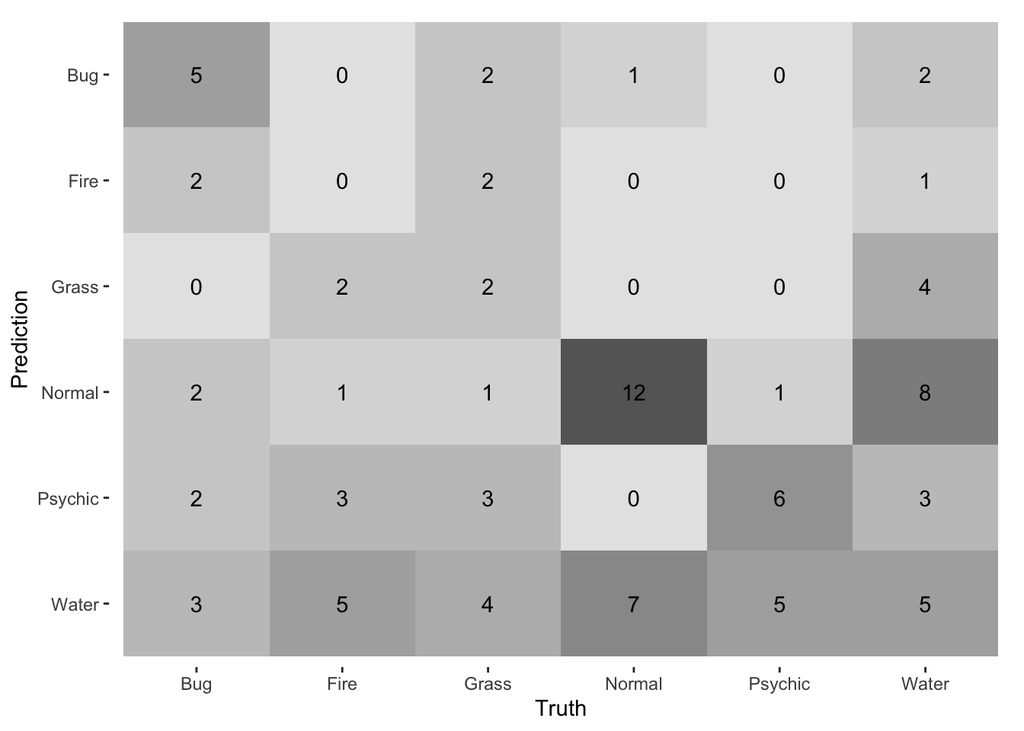

```r
# make heat map of the confusoin matrix
predicted_data %>%
  conf_mat(truth = type_1, .pred_class) %>%
  autoplot(type="heatmap")
```

It appears that the model isn’t super effective based on the confusion matrix. The model performed better than a coin flip since the ROC AUC was greater than 0.5. However, the ROC AUC value of 0.677 does not represent a very accurate model. The model was most effective at predicting normal primary types. This may be because pokemons in that class tend to display similar characteristics. The model is least effective at predicting fire and water types. This may be because there is greater diversity in the characteristics exhibited by pokemons in these classes.